# Thomas Analysis

Thomas Schindler

29 November 2017

# Background

Here I focus on data analysis sampled during Summer School 2017 in Agali forest. Any collected data belong to greenhouse gas emissions by grey alder stems during the experiment phase. Basically, the experiment consisted of three periods - before, during, and afterartificial irrigation of the forest. There are two groups of stem chambers, one located at the irrigation area (Tree 01 - 08, 12), the control group consists of trees 09-11. Further, the stem chambers are located on three heights. Exceptions are made at trees: 01, 05, 07, and 10 where chambers are situated at the bottom level only.

# Libraries to load

```r
library(tidyverse)
library(tidyr)
library(ggthemes)
library(xtable)
library(ggplot2)
library(stringr)
library(scales)
library(cowplot)
library(Rmisc)
library(dplyr)
```

# N2O Data Import

```r
dat<- read.csv("n2oR.csv", header = TRUE)
```

```r
dat
```

```
##       Sampled Tree1h0 Tree2h0 Tree3h0 Tree4h0 Tree5h0 Tree6h0 Tree7h0
## 1  2017-07-05      NA   0.000   1.382  16.030      NA   0.662      NA
## 2  2017-07-18      NA   0.000   0.000  38.508      NA   0.004      NA
## 3  2017-07-20   0.000   0.037   0.054  23.783   4.390  11.373   4.277
## 4  2017-07-24   0.000   0.023   0.091  12.524   2.590   0.000   0.664
## 5  2017-07-26   0.000   0.000   0.000   9.760   0.542   0.000   1.210
## 6  2017-07-27   0.365   0.000   0.000   6.784   3.074   0.000   1.510
## 7  2017-07-31   0.000   0.120   0.226   6.195   3.195   0.084   0.404
## 8  2017-08-02   0.021   0.212   0.013   2.773   2.780   0.000   0.339
## 9  2017-08-03   0.194   0.000   0.000   3.962   3.439   0.000   0.097
## 10 2017-08-07   0.000   0.000   4.343   4.098  14.918   0.123  12.083
## 11 2017-08-09   1.233   0.208   1.157  10.757   5.608   7.415  25.815
## 12 2017-08-10      NA      NA      NA      NA      NA   9.332  72.559
## 13 2017-08-14   0.000   0.120   9.990  19.078  34.049   1.776   3.990
## 14 2017-08-16   0.000   0.049   3.465  11.916   7.074   2.301   2.912
```

[output cut: 69 more lines]

# Data are still in wrong format (wide instead of long)

Thus, original data table needs to be converted /gathered - library ‘tidyr’ to be added to library list at the beginning

The arguments to gather(): - data: Data object - key: Name of new key column (made from names of data columns) - value: Name of new value column - …: Names of source columns that contain values - factor_key: Treat the new key column as a factor (instead of character vector)

### Re-Organising Data Colums, experimental sites

Zero level, experimental site

```r
  n2o0 <- gather(dat, "olevel", "flux", Tree1h0:Tree12h0, factor_key=TRUE)
```

```r
n2o0
```

```
##        Sampled Tree2h80 Tree3h80 Tree4h80 Tree6h80 Tree8h80 Tree12h80
## 1   2017-07-05    0.000    0.000    6.130    0.251    0.000        NA
## 2   2017-07-18    0.010    0.000   11.169    0.000    2.399        NA
## 3   2017-07-20    0.000    0.213    9.490    0.000    1.994     0.330
## 4   2017-07-24    0.000    0.055    2.263    0.000    3.306     0.426
## 5   2017-07-26    0.000    0.055    0.389    0.209    0.055     0.000
## 6   2017-07-27    0.000    0.197    3.264    0.000    2.152     0.000
## 7   2017-07-31    0.000    0.000    0.049    0.000    0.170     0.000
## 8   2017-08-02    0.000    0.000    0.223    0.000    0.720     0.000
## 9   2017-08-03    0.085    0.073    0.096    0.000    1.531     0.000
## 10  2017-08-07    0.197    4.465    8.789    0.246    0.749     1.210
## 11  2017-08-09    0.343    3.464    5.675    3.080    2.519     0.391
## 12  2017-08-10       NA       NA       NA    6.294    6.592     0.000
## 13  2017-08-14    0.106    6.867   18.065    0.088    0.499     0.406
## 14  2017-08-16    0.000    2.559    7.558    0.251    0.890     1.158
```

[output cut: 709 more lines]

80cm Level, experimental site

```r
  n2o80 <- gather(dat, "80level", "flux", Tree2h80:Tree12h80, factor_key=TRUE)
```

```r
n2o80
```

```
##        Sampled Tree1h0 Tree2h0 Tree3h0 Tree4h0 Tree5h0 Tree6h0 Tree7h0
## 1   2017-07-05      NA   0.000   1.382  16.030      NA   0.662      NA
## 2   2017-07-18      NA   0.000   0.000  38.508      NA   0.004      NA
## 3   2017-07-20   0.000   0.037   0.054  23.783   4.390  11.373   4.277
## 4   2017-07-24   0.000   0.023   0.091  12.524   2.590   0.000   0.664
## 5   2017-07-26   0.000   0.000   0.000   9.760   0.542   0.000   1.210
## 6   2017-07-27   0.365   0.000   0.000   6.784   3.074   0.000   1.510
## 7   2017-07-31   0.000   0.120   0.226   6.195   3.195   0.084   0.404
## 8   2017-08-02   0.021   0.212   0.013   2.773   2.780   0.000   0.339
## 9   2017-08-03   0.194   0.000   0.000   3.962   3.439   0.000   0.097
## 10  2017-08-07   0.000   0.000   4.343   4.098  14.918   0.123  12.083
## 11  2017-08-09   1.233   0.208   1.157  10.757   5.608   7.415  25.815
## 12  2017-08-10      NA      NA      NA      NA      NA   9.332  72.559
## 13  2017-08-14   0.000   0.120   9.990  19.078  34.049   1.776   3.990
## 14  2017-08-16   0.000   0.049   3.465  11.916   7.074   2.301   2.912
```

[output cut: 469 more lines]

170cm Level, experimental site

```r
  n2o170 <- gather(dat, "170level", "flux", Tree2h170:Tree12h170, factor_key=TRUE)
```

```r
n2o170
```

```
##        Sampled Tree1h0 Tree2h0 Tree3h0 Tree4h0 Tree5h0 Tree6h0 Tree7h0
## 1   2017-07-05      NA   0.000   1.382  16.030      NA   0.662      NA
## 2   2017-07-18      NA   0.000   0.000  38.508      NA   0.004      NA
## 3   2017-07-20   0.000   0.037   0.054  23.783   4.390  11.373   4.277
## 4   2017-07-24   0.000   0.023   0.091  12.524   2.590   0.000   0.664
## 5   2017-07-26   0.000   0.000   0.000   9.760   0.542   0.000   1.210
## 6   2017-07-27   0.365   0.000   0.000   6.784   3.074   0.000   1.510
## 7   2017-07-31   0.000   0.120   0.226   6.195   3.195   0.084   0.404
## 8   2017-08-02   0.021   0.212   0.013   2.773   2.780   0.000   0.339
## 9   2017-08-03   0.194   0.000   0.000   3.962   3.439   0.000   0.097
## 10  2017-08-07   0.000   0.000   4.343   4.098  14.918   0.123  12.083
## 11  2017-08-09   1.233   0.208   1.157  10.757   5.608   7.415  25.815
## 12  2017-08-10      NA      NA      NA      NA      NA   9.332  72.559
## 13  2017-08-14   0.000   0.120   9.990  19.078  34.049   1.776   3.990
## 14  2017-08-16   0.000   0.049   3.465  11.916   7.074   2.301   2.912
```

[output cut: 469 more lines]

# Re-Organising Data Colums, control sites

```r
  n2o0c <- gather(dat, "olevelC", "flux", Tree9h0:Tree11h0, factor_key=TRUE)
```

```r
n2o0c
```

```
##       Sampled Tree1h0 Tree2h0 Tree3h0 Tree4h0 Tree5h0 Tree6h0 Tree7h0
## 1  2017-07-05      NA   0.000   1.382  16.030      NA   0.662      NA
## 2  2017-07-18      NA   0.000   0.000  38.508      NA   0.004      NA
## 3  2017-07-20   0.000   0.037   0.054  23.783   4.390  11.373   4.277
## 4  2017-07-24   0.000   0.023   0.091  12.524   2.590   0.000   0.664
## 5  2017-07-26   0.000   0.000   0.000   9.760   0.542   0.000   1.210
## 6  2017-07-27   0.365   0.000   0.000   6.784   3.074   0.000   1.510
## 7  2017-07-31   0.000   0.120   0.226   6.195   3.195   0.084   0.404
## 8  2017-08-02   0.021   0.212   0.013   2.773   2.780   0.000   0.339
## 9  2017-08-03   0.194   0.000   0.000   3.962   3.439   0.000   0.097
## 10 2017-08-07   0.000   0.000   4.343   4.098  14.918   0.123  12.083
## 11 2017-08-09   1.233   0.208   1.157  10.757   5.608   7.415  25.815
## 12 2017-08-10      NA      NA      NA      NA      NA   9.332  72.559
## 13 2017-08-14   0.000   0.120   9.990  19.078  34.049   1.776   3.990
## 14 2017-08-16   0.000   0.049   3.465  11.916   7.074   2.301   2.912
```

[output cut: 229 more lines]

```r
  n2o80c <- gather(dat, "80levelC", "flux", Tree9h80:Tree11h80, factor_key=TRUE)
```

```r
  n2o80c
```

```
##       Sampled Tree1h0 Tree2h0 Tree3h0 Tree4h0 Tree5h0 Tree6h0 Tree7h0
## 1  2017-07-05      NA   0.000   1.382  16.030      NA   0.662      NA
## 2  2017-07-18      NA   0.000   0.000  38.508      NA   0.004      NA
## 3  2017-07-20   0.000   0.037   0.054  23.783   4.390  11.373   4.277
## 4  2017-07-24   0.000   0.023   0.091  12.524   2.590   0.000   0.664
## 5  2017-07-26   0.000   0.000   0.000   9.760   0.542   0.000   1.210
## 6  2017-07-27   0.365   0.000   0.000   6.784   3.074   0.000   1.510
## 7  2017-07-31   0.000   0.120   0.226   6.195   3.195   0.084   0.404
## 8  2017-08-02   0.021   0.212   0.013   2.773   2.780   0.000   0.339
## 9  2017-08-03   0.194   0.000   0.000   3.962   3.439   0.000   0.097
## 10 2017-08-07   0.000   0.000   4.343   4.098  14.918   0.123  12.083
## 11 2017-08-09   1.233   0.208   1.157  10.757   5.608   7.415  25.815
## 12 2017-08-10      NA      NA      NA      NA      NA   9.332  72.559
## 13 2017-08-14   0.000   0.120   9.990  19.078  34.049   1.776   3.990
## 14 2017-08-16   0.000   0.049   3.465  11.916   7.074   2.301   2.912
```

[output cut: 149 more lines]

```r
  n2o170c <- gather(dat, "170levelC", "flux", Tree9h170:Tree11h170, factor_key=TRUE)
```

```r
n2o170c
```

```
##       Sampled Tree1h0 Tree2h0 Tree3h0 Tree4h0 Tree5h0 Tree6h0 Tree7h0
## 1  2017-07-05      NA   0.000   1.382  16.030      NA   0.662      NA
## 2  2017-07-18      NA   0.000   0.000  38.508      NA   0.004      NA
## 3  2017-07-20   0.000   0.037   0.054  23.783   4.390  11.373   4.277
## 4  2017-07-24   0.000   0.023   0.091  12.524   2.590   0.000   0.664
## 5  2017-07-26   0.000   0.000   0.000   9.760   0.542   0.000   1.210
## 6  2017-07-27   0.365   0.000   0.000   6.784   3.074   0.000   1.510
## 7  2017-07-31   0.000   0.120   0.226   6.195   3.195   0.084   0.404
## 8  2017-08-02   0.021   0.212   0.013   2.773   2.780   0.000   0.339
## 9  2017-08-03   0.194   0.000   0.000   3.962   3.439   0.000   0.097
## 10 2017-08-07   0.000   0.000   4.343   4.098  14.918   0.123  12.083
## 11 2017-08-09   1.233   0.208   1.157  10.757   5.608   7.415  25.815
## 12 2017-08-10      NA      NA      NA      NA      NA   9.332  72.559
## 13 2017-08-14   0.000   0.120   9.990  19.078  34.049   1.776   3.990
## 14 2017-08-16   0.000   0.049   3.465  11.916   7.074   2.301   2.912
```

[output cut: 149 more lines]

# ! Data now look much better

# N2O Boxplots from Experimental Site, no control spots, Level 0/80/170 cm

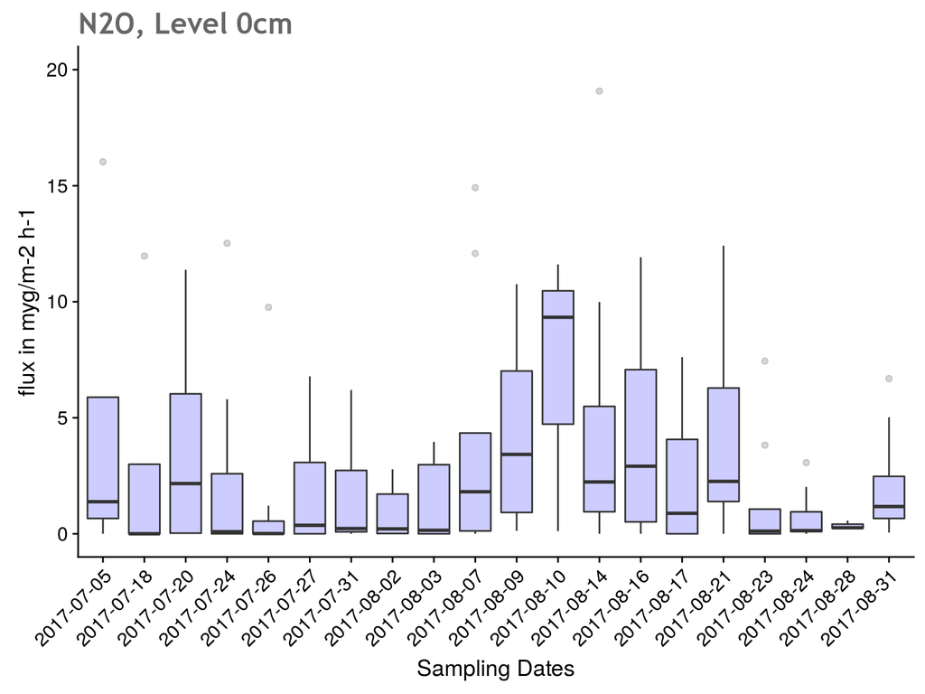

```r
  e1 <- ggplot(n2o0,
              aes(x=Sampled,
                  y=flux))
  e1 <- e1 +
        geom_boxplot(fill="blue", alpha=0.2) +
          ggtitle("N2O, Level 0cm") +
          labs(x="Sampling Dates", y="N2O flux") +
          theme(plot.title = element_text(family = "Trebuchet MS", color="#666666", face="bold", size=18, hjust=0)) +
          theme(axis.text.x = element_text(angle = 45, hjust = 1)) +
          scale_y_continuous(name="flux in myg/m-2 h-1", limits=c(0, 20))
```

```r
  e2 <- ggplot(n2o80,
              aes(x=Sampled,
                  y=flux))
  e2 <- e2 +
        geom_boxplot(fill="blue", alpha=0.2) +
          ggtitle("N2O, Level 80cm") +
          labs(x="Sampling Dates", y="N2O flux") +
          theme(plot.title = element_text(family = "Trebuchet MS", color="#666666", face="bold", size=18, hjust=0)) +
          theme(axis.text.x = element_text(angle = 45, hjust = 1)) +
          scale_y_continuous(name="flux in myg/m-2 h-1", limits=c(0, 20))
```

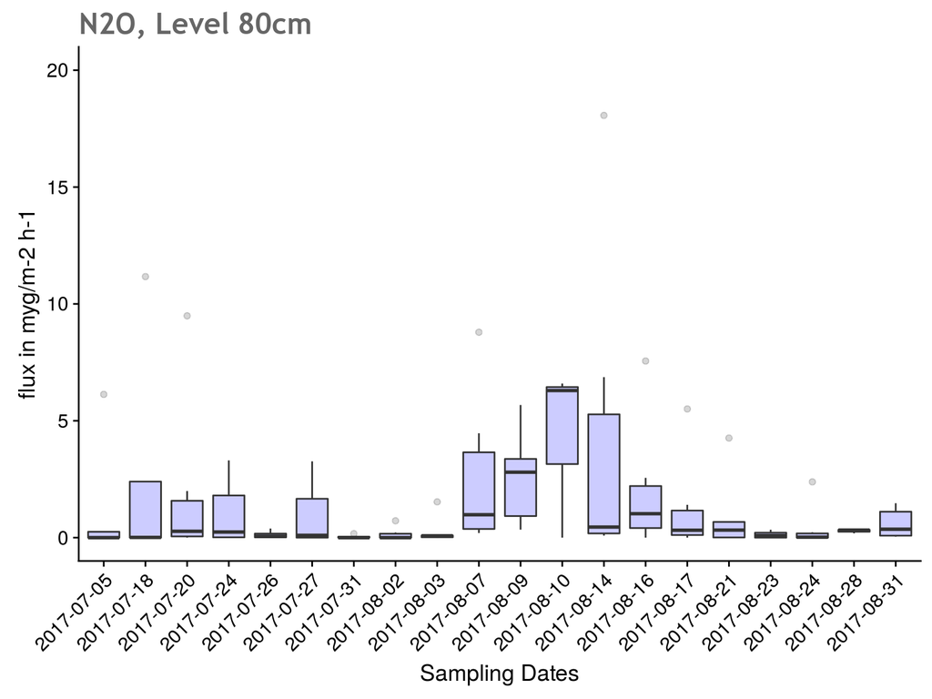

```r
  e2
```

```r
  e3 <- ggplot(n2o170,
              aes(x=Sampled,
                  y=flux))
  e3 <- e3 +
        geom_boxplot(fill="blue", alpha=0.2) +
          ggtitle("N2O, Level 180cm") +
          labs(x="Sampling Dates", y="N2O flux") +
          theme(plot.title = element_text(family = "Trebuchet MS", color="#666666", face="bold", size=18, hjust=0)) +
          theme(axis.text.x = element_text(angle = 45, hjust = 1)) +
          scale_y_continuous(name="flux in myg/m-2 h-1", limits=c(0, 20))
```

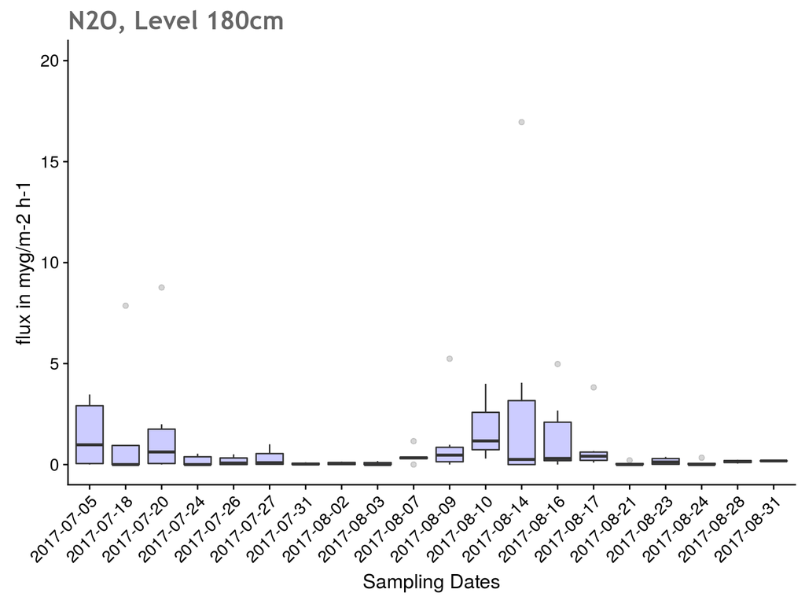

```r
  e3
```

# Multiplot Plot N2O Fluxes from Experimental Sites somehow produces S***

```r
    library(gridExtra)
```

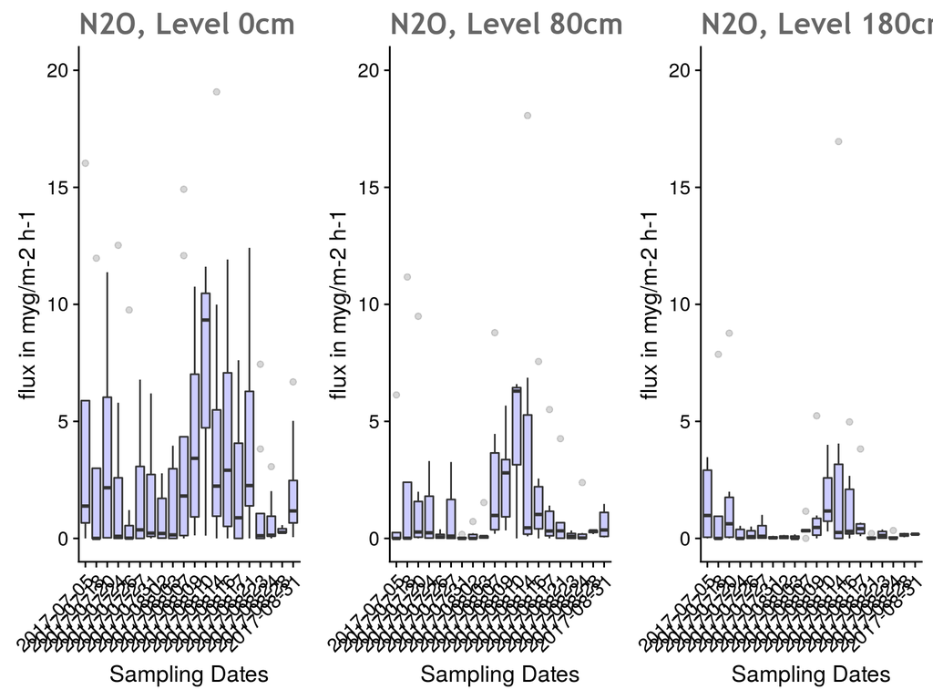

```r
    library(grid)
   grid.arrange(e1, e2, e3, ncol=3)
```